# STAT 184 Final Project

Superhero Attributes

Jessica Eshenbaugh

## Front Matter

```r
# clean up workspace environment
rm(list = ls())

## load required tables/packages
library(mosaic)
library(tidyverse)
library(ggplot2)
library(rvest)

## load data set (DC)
library(readr)
DC <- read_csv("dc-wikia-data.csv")
## load data set (Marvel)
library(readr)
Marvel <- read_csv("marvel-wikia-data.csv")
```

## Guiding Question

With all of the recent movements happening throughout the country, one of the issues that has been brought to light is the under-representation of minorities of all sorts throughout various mediums, and also how they are misrepresented. The data I will be looking at is data on superheroes. One set is for Marvel, the other DC. It has various attributes of the character, including whether they are a sexual or gender minority or not. My question is: How does whether a superhero is a gender or sexual minority affect their attributes (ie number of appearances, year of appearance, etc) in these comic companies?

## Become Acquainted With Data Sources:

- I found this data on the website “Kaggle”
- It was collected by a company called “FiveThirtyEight”, and they scraped it from Marvel and DC Wikia
- The data was originally collected to look at the under-representation of women in comic books. It was collected in 2018, on about August 24.
- A case represents a superhero/villain from either Marvel or DC (depending on the data set you’re looking at)
- Some of the variables I plan on looking at are ‘APPEARANCES’, ‘NAME’, ‘ALIGN’, ‘SEX’, ‘GSM’, ‘ALIVE’, ‘FIRST APPEARANCE’, and ‘YEAR’

```r
## look at data sets
str(Marvel)
```

```
Classes ‘spec_tbl_df’, ‘tbl_df’, ‘tbl’ and 'data.frame':    15742 obs. of  13 variables:
 $ page_id         : num  1678 7139 64786 1868 2460 ...
 $ name            : chr  "Spider-Man (Peter Parker)" "Captain America (Steven Rogers)" "Wolverine (James \\\"Logan\\\" Howlett)" "Iron Man (Anthony \\\"Tony\\\" Stark)" ...
 $ urlslug         : chr  "\\/Spider-Man_(Peter_Parker)" "\\/Captain_America_(Steven_Rogers)" "\\/Wolverine_(James_%22Logan%22_Howlett)" "\\/Iron_Man_(Anthony_%22Tony%22_Stark)" ...
 $ ID              : chr  "Secret Identity" "Public Identity" "Public Identity" "Public Identity" ...
 $ ALIGN           : chr  "Good Characters" "Good Characters" "Neutral Characters" "Good Characters" ...
 $ EYE             : chr  "Hazel Eyes" "Blue Eyes" "Blue Eyes" "Blue Eyes" ...
 $ HAIR            : chr  "Brown Hair" "White Hair" "Black Hair" "Black Hair" ...
 $ SEX             : chr  "Male Characters" "Male Characters" "Male Characters" "Male Characters" ...
 $ GSM             : chr  NA NA NA NA ...
 $ ALIVE           : chr  "Living Characters" "Living Characters" "Living Characters" "Living Characters" ...
 $ APPEARANCES     : num  4043 3360 3061 2961 2258 ...
 $ FIRST APPEARANCE: chr  "Aug-62" "Mar-41" "Oct-74" "Mar-63" ...
 $ Year            : num  1962 1941 1974 1963 1950 ...
 - attr(*, "problems")=Classes ‘tbl_df’, ‘tbl’ and 'data.frame':    1 obs. of  5 variables:
  ..$ row     : int 15742
  ..$ col     : chr NA
  ..$ expected: chr "13 columns"
  ..$ actual  : chr "3 columns"
  ..$ file    : chr "'marvel-wikia-data.csv'"
 - attr(*, "spec")=
  .. cols(
  ..   page_id = col_double(),
  ..   name = col_character(),
  ..   urlslug = col_character(),
  ..   ID = col_character(),
  ..   ALIGN = col_character(),
  ..   EYE = col_character(),
  ..   HAIR = col_character(),
  ..   SEX = col_character(),
  ..   GSM = col_character(),
  ..   ALIVE = col_character(),
  ..   APPEARANCES = col_double(),
  ..   `FIRST APPEARANCE` = col_character(),
  ..   Year = col_double()
  .. )
```

```r
head(Marvel)
```

| page_id | name | urlslug | ID | ALIGN | EYE | HAIR | SEX | GSM | ALIVE | APPEARANCES | FIRST APPEARANCE | Year |
| --- | --- | --- | --- | --- | --- | --- | --- | --- | --- | --- | --- | --- |
| 1678 | Spider-Man (Peter Parker) | \\/Spider-Man_(Peter_Parker) | Secret Identity | Good Characters | Hazel Eyes | Brown Hair | Male Characters | NA | Living Characters | 4043 | Aug-62 | 1962 |
| 7139 | Captain America (Steven Rogers) | \\/Captain_America_(Steven_Rogers) | Public Identity | Good Characters | Blue Eyes | White Hair | Male Characters | NA | Living Characters | 3360 | Mar-41 | 1941 |
| 64786 | Wolverine (James \\"Logan\\" Howlett) | \\/Wolverine_(James_%22Logan%22_Howlett) | Public Identity | Neutral Characters | Blue Eyes | Black Hair | Male Characters | NA | Living Characters | 3061 | Oct-74 | 1974 |
| 1868 | Iron Man (Anthony \\"Tony\\" Stark) | \\/Iron_Man_(Anthony_%22Tony%22_Stark) | Public Identity | Good Characters | Blue Eyes | Black Hair | Male Characters | NA | Living Characters | 2961 | Mar-63 | 1963 |
| 2460 | Thor (Thor Odinson) | \\/Thor_(Thor_Odinson) | No Dual Identity | Good Characters | Blue Eyes | Blond Hair | Male Characters | NA | Living Characters | 2258 | Nov-50 | 1950 |
| 2458 | Benjamin Grimm (Earth-616) | \\/Benjamin_Grimm_(Earth-616) | Public Identity | Good Characters | Blue Eyes | No Hair | Male Characters | NA | Living Characters | 2255 | Nov-61 | 1961 |

```r
str(DC)
```

```
Classes ‘spec_tbl_df’, ‘tbl_df’, ‘tbl’ and 'data.frame':    6896 obs. of  13 variables:
 $ page_id         : num  1422 23387 1458 1659 1576 ...
 $ name            : chr  "Batman (Bruce Wayne)" "Superman (Clark Kent)" "Green Lantern (Hal Jordan)" "James Gordon (New Earth)" ...
 $ urlslug         : chr  "\\/wiki\\/Batman_(Bruce_Wayne)" "\\/wiki\\/Superman_(Clark_Kent)" "\\/wiki\\/Green_Lantern_(Hal_Jordan)" "\\/wiki\\/James_Gordon_(New_Earth)" ...
 $ ID              : chr  "Secret Identity" "Secret Identity" "Secret Identity" "Public Identity" ...
 $ ALIGN           : chr  "Good Characters" "Good Characters" "Good Characters" "Good Characters" ...
 $ EYE             : chr  "Blue Eyes" "Blue Eyes" "Brown Eyes" "Brown Eyes" ...
 $ HAIR            : chr  "Black Hair" "Black Hair" "Brown Hair" "White Hair" ...
 $ SEX             : chr  "Male Characters" "Male Characters" "Male Characters" "Male Characters" ...
 $ GSM             : chr  NA NA NA NA ...
 $ ALIVE           : chr  "Living Characters" "Living Characters" "Living Characters" "Living Characters" ...
 $ APPEARANCES     : num  3093 2496 1565 1316 1237 ...
 $ FIRST APPEARANCE: chr  "1939, May" "1986, October" "1959, October" "1987, February" ...
 $ YEAR            : num  1939 1986 1959 1987 1940 ...
 - attr(*, "spec")=
  .. cols(
  ..   page_id = col_double(),
  ..   name = col_character(),
  ..   urlslug = col_character(),
  ..   ID = col_character(),
  ..   ALIGN = col_character(),
  ..   EYE = col_character(),
  ..   HAIR = col_character(),
  ..   SEX = col_character(),
  ..   GSM = col_character(),
  ..   ALIVE = col_character(),
  ..   APPEARANCES = col_double(),
  ..   `FIRST APPEARANCE` = col_character(),
  ..   YEAR = col_double()
  .. )
```

```r
head(DC)
```

| page_id | name | urlslug | ID | ALIGN | EYE | HAIR | SEX | GSM | ALIVE | APPEARANCES | FIRST APPEARANCE | YEAR |
| --- | --- | --- | --- | --- | --- | --- | --- | --- | --- | --- | --- | --- |
| 1422 | Batman (Bruce Wayne) | \\/wiki\\/Batman_(Bruce_Wayne) | Secret Identity | Good Characters | Blue Eyes | Black Hair | Male Characters | NA | Living Characters | 3093 | 1939, May | 1939 |
| 23387 | Superman (Clark Kent) | \\/wiki\\/Superman_(Clark_Kent) | Secret Identity | Good Characters | Blue Eyes | Black Hair | Male Characters | NA | Living Characters | 2496 | 1986, October | 1986 |
| 1458 | Green Lantern (Hal Jordan) | \\/wiki\\/Green_Lantern_(Hal_Jordan) | Secret Identity | Good Characters | Brown Eyes | Brown Hair | Male Characters | NA | Living Characters | 1565 | 1959, October | 1959 |
| 1659 | James Gordon (New Earth) | \\/wiki\\/James_Gordon_(New_Earth) | Public Identity | Good Characters | Brown Eyes | White Hair | Male Characters | NA | Living Characters | 1316 | 1987, February | 1987 |
| 1576 | Richard Grayson (New Earth) | \\/wiki\\/Richard_Grayson_(New_Earth) | Secret Identity | Good Characters | Blue Eyes | Black Hair | Male Characters | NA | Living Characters | 1237 | 1940, April | 1940 |
| 1448 | Wonder Woman (Diana Prince) | \\/wiki\\/Wonder_Woman_(Diana_Prince) | Public Identity | Good Characters | Blue Eyes | Black Hair | Female Characters | NA | Living Characters | 1231 | 1941, December | 1941 |

## Explore intuition related to the research question with pairs of variables

### Make the Data More User-Friendly

```r
## make the variable 'FIRST APPEARANCE' easier to work with
Marvel <-
  Marvel %>%
  mutate(first_app = "FIRST APPEARANCE")
DC <-
  DC %>%
  mutate(first_app = "FIRST APPEARANCE")
```

```r
## filter out variables that won't be used
Marvel <-
  Marvel %>%
  select(name, ID, ALIGN, EYE, HAIR, SEX, GSM, ALIVE, APPEARANCES, first_app, Year)
DC <-
  DC %>%
  select(name, ID, ALIGN, EYE, HAIR, SEX, GSM, ALIVE, APPEARANCES, first_app, YEAR)
```

In this case, the NA values in the GSM variable are for non-minority characters, as it was explained that FiveThirtyEight specified any character/character type that was a minority, so I have to change the NA values within GSM to “non-minority”. I will also change the Marvel dataset variable “Year” to “YEAR” so that the variable name matches the corresponding DC dataset variable.

```r
## replace NA values in GSM with 'non-minority' (Marvel)
Marvel <-
  Marvel %>%
  mutate(GSM = replace(GSM, is.na(GSM), "non-minority"))
## replace NA values in GSM with 'non-minority' (DC)
DC <-
  DC %>%
  mutate(GSM = replace(GSM, is.na(GSM), "non-minority"))
## make the data set easier to work with
Marvel <-
  Marvel %>%
  rename(YEAR = Year)
```

While looking at Marvel and DC comic’s data separately can be useful, it may also prove useful to look at the combined data, so I will make a combined dataset for further analysis of the trends.

```r
# make a combined dataset for further analysis
## make new variable that has the comic's name
Marvel_combo <-
  Marvel %>%
  mutate(comic = "Marvel")
DC_combo <-
  DC %>%
  mutate(comic = "DC")
```

```r
## combine the two tables
Hero <-
  Marvel_combo %>%
  bind_rows(DC_combo)
```

### Look at the number of characters in relation to GSM

I suspect that a number of the variables within the data set (including ALGIN, APPEARANCES, FIRST APPEARANCE, YEAR, SEX, and ID) are affected by the variable GSM (whether the character is a sexual/gender minority or not). I will first begin by looking at the bar graph of total number of minority characters within each comic book company.

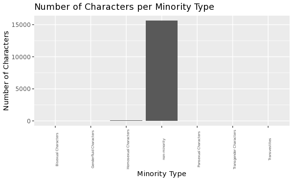

```r
Marvel %>%
  ggplot(aes(x = GSM)) +
  geom_bar() +
  theme(axis.text.x = element_text(face="plain", size=5, angle=90)) + # make the x-axis labels fit
  labs(x = "Minority Type", y = "Number of Characters", title = "Number of Characters per Minority Type")
```

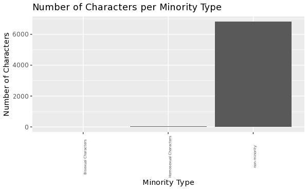

```r
DC %>%
  ggplot(aes(x = GSM)) +
  geom_bar() +
  theme(axis.text.x = element_text(face="plain", size=5, angle=90)) + # make the x-axis labels fit
  labs(x = "Minority Type", y = "Number of Characters", title = "Number of Characters per Minority Type")
```

Based on these summary statistics, it appears that both Marvel and DC have more a large amount more non-minority characters than it does minority, and notably DC has not only less minority characters overall, but also less of a range of minority characters. This may be due to the fact when the data was collected a couple years ago, when gay rights were more of a debate than fact, and the lack of transgender or pansexual characters may have been due to the fact that there wasn’t much of a conversation around these issues/minorities at that time. To confirm what was seen in the bar graph, I will look at the summary statistics of each comic.

```r
## find how many characters are of a minority (Marvel)
Marvel %>%
  group_by(GSM) %>%
  summarise(total = n()) %>%
  arrange(desc(total))
```

| GSM | total |
| --- | --- |
| non-minority | 15656 |
| Homosexual Characters | 62 |
| Bisexual Characters | 19 |
| Transgender Characters | 2 |
| Genderfluid Characters | 1 |
| Pansexual Characters | 1 |
| Transvestites | 1 |

```r
## find how many characters are a minority (DC)
DC %>%
  group_by(GSM) %>%
  summarise(total = n()) %>%
  arrange(desc(total))
```

| GSM | total |
| --- | --- |
| non-minority | 6832 |
| Homosexual Characters | 54 |
| Bisexual Characters | 10 |

This confirms what the graph above has shown above; in Marvel, there is a lot more non-minority characters than there are others (15,656 characters to the next highest, which is 62). DC follows a similar trend, but it is somewhat less dramatic of a drop-off between non-minority and minority characters, when compared to that of Marvel. Now, I will look at the data sets overall

```r
Hero %>%
  group_by(GSM) %>%
  summarise(total_characters = n_distinct(name))
```

| GSM | total_characters |
| --- | --- |
| Bisexual Characters | 29 |
| Genderfluid Characters | 1 |
| Homosexual Characters | 116 |
| non-minority | 22488 |
| Pansexual Characters | 1 |
| Transgender Characters | 2 |
| Transvestites | 1 |

The two data sets combined still follow this trend of having by far more non-minority characters than minority; however, it follows the more dramatic drop-off between minority and non-minority characters that the Marvel had, rather than the less noticeable drop-off DC comics had.

### Look at GSM and Appearances

I theorize that GSM may also have an affect on the number of appearances. Based on the issue of under-representation within minority groups such as these, I would assume that minority characters make less total appearances in comics than non-minority characters.

```r
## find how many appearances minority characters make (Marvel)
Marvel %>%
  group_by(GSM) %>%
  na.omit() %>%
  summarise(total_appearances = sum(APPEARANCES)) %>%
  arrange(desc(total_appearances))
```

| GSM | total_appearances |
| --- | --- |
| non-minority | 193046 |
| Bisexual Characters | 4610 |
| Homosexual Characters | 2124 |
| Transvestites | 500 |
| Pansexual Characters | 150 |
| Genderfluid Characters | 33 |

```r
## find how many appearances minority characters make (DC)
DC %>%
  group_by(GSM) %>%
  na.omit() %>%
  summarise(total_appearances = sum(APPEARANCES)) %>%
  arrange(desc(total_appearances))
```

| GSM | total_appearances |
| --- | --- |
| non-minority | 96771 |
| Homosexual Characters | 1538 |
| Bisexual Characters | 645 |

Out of all the minority characters, it appears that bisexual characters made the most appearances in Marvel, by over twice that of the second highest amount of appearances within minorities. In DC comics, it appears that ‘homosexual’ has the most appearances in comics. Overall, however, non-minority has by far the most appearances in comics. This is what I expected, it seems as though non-minority characters are far more popular in comic books. Perhaps bisexual/homosexual characters were included the most out of all the minority characters categories because, in the US, they are the majority of people out of these minority categories. To further look at this apparent trend of non-minorities having more appearances, I will find the total appearances of each minority group, then separate non-minority from the minorities, spread the data based on GSM, and find the difference of non-minority appearances and the sum of all the other minority appearances.

```r
## make data set that finds the total appearances for each minority type
Hero_total <-
  Hero %>%
  na.omit() %>%
  group_by(GSM) %>%
  summarise(total = sum(APPEARANCES))
## pick only the minority (all minority's end in 's')
Hero_min <-
  Hero_total %>%
  filter(grepl("s$", GSM))
## pick only non-minority
Hero_non_min <-
  Hero_total %>%
  filter(grepl("y$", GSM))
```

```r
## spread data table based on minority
Hero_spread_min <-
  Hero_min %>%
  spread(key = GSM, value = total)
knitr::kable(Hero_spread_min)
```

| Bisexual Characters | Genderfluid Characters | Homosexual Characters | Pansexual Characters | Transvestites |
| --- | --- | --- | --- | --- |
| 5255 | 33 | 3662 | 150 | 500 |

```r
## spread data table based on non-minority
Hero_spread_nm <-
  Hero_non_min %>%
  spread(key = GSM, value = total)
knitr::kable(Hero_spread_nm)
```

| non-minority |
| --- |
| 289817 |

```r
app_diff <- function(x, y) {
  z <- x - sum(y)
  paste("The difference between non-minority and all minority appearances is", z)
}
```

```r
app_diff(Hero_spread_nm, Hero_spread_min)
```

```
[1] "The difference between non-minority and all minority appearances is 280217"
```

### Look at GSM in relation to Sex

Another interesting thing to look at is how GSM and SEX may interact with one another. I suspect that within each minority, the male sex will be most common, simply because male characters are more common within comic books.

```r
Marvel %>%
  group_by(SEX, GSM) %>%
  summarise(total = n()) %>%
  arrange(desc(total))
```

| SEX | GSM | total |
| --- | --- | --- |
| Male Characters | non-minority | 11173 |
| Female Characters | non-minority | 3642 |
| NA | non-minority | 797 |
| Agender Characters | non-minority | 44 |
| Male Characters | Homosexual Characters | 40 |
| Female Characters | Homosexual Characters | 22 |
| Female Characters | Bisexual Characters | 13 |
| Male Characters | Bisexual Characters | 5 |
| Female Characters | Transgender Characters | 2 |
| Female Characters | Pansexual Characters | 1 |

[output cut: 3 more lines]

```r
DC %>%
  group_by(SEX, GSM) %>%
  summarise(total = n()) %>%
  arrange(desc(total))
```

| SEX | GSM | total |
| --- | --- | --- |
| Male Characters | non-minority | 4749 |
| Female Characters | non-minority | 1938 |
| NA | non-minority | 125 |
| Male Characters | Homosexual Characters | 30 |
| Female Characters | Homosexual Characters | 24 |
| Genderless Characters | non-minority | 19 |
| Female Characters | Bisexual Characters | 5 |
| Male Characters | Bisexual Characters | 4 |
| Genderless Characters | Bisexual Characters | 1 |
| Transgender Characters | non-minority | 1 |

It appears that within minority characters for Marvel, male homosexual characters are more common, which confirms (at least for the ‘homosexual’ category) my theory that men would be more common. However, for the categories of bisexual, transgender, and pansexual, it appears that female characters are more common, disproving my theory that men would be predominant. To look at this possible trend better overall, I will make a bar graph of sex and GSM, to see if the data sets as a whole follow this trend.

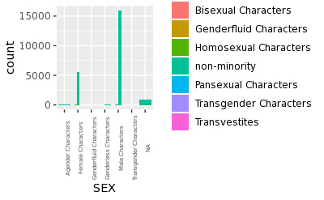

```r
Hero %>%
  ggplot(aes(x = SEX)) +
  geom_bar(aes(fill = GSM), position = "dodge") +
  theme(axis.text.x = element_text(face="plain", size=5, angle=90)) # make the x-axis labels fit
```

```r
  labs(x = "Sex", y = "Number of Characters", title = "Number of Characters in relation to sex and minority type")
```

```
$x
[1] "Sex"

$y
[1] "Number of Characters"

$title
[1] "Number of Characters in relation to sex and minority type"

attr(,"class")
[1] "labels"
```

This helps to confirm what was seen above, with non-minority characters having the most characters overall, and that non-minority male characters are the most common characters out of all the non-minority sexes.

## Explore intuition related to the research question with 3+ variables

Now that I have done some summary statistics and observations into how pairs of some of the variables interact, I will now go further in-depth by looking at how three or more variables interact.

### Look at how GSM, Year, and Appearances interact

Another thing that might be interesting is the year a minority character first appeared. Gay marriage wasn’t legalized until 2015, so many comic books may not have had many minority characters up until that point. So, the minority characters, such as ‘homosexual’ may not appear until later years (2015-2018), which conversely may cause their number of appearances to be less than those of non-minority, some of whom have been around since the 1940’s

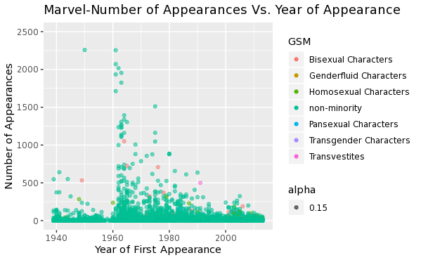

```r
Marvel %>%
  ggplot(aes(x = YEAR, y = APPEARANCES)) +
  geom_point(aes(color = GSM, group = GSM, alpha = 0.15)) +
  ylim(0, 2500) + ## get rid of outliers
  labs(x = "Year of First Appearance", y = "Number of Appearances", title = "Marvel-Number of Appearances Vs. Year of Appearance")
```

It does appear that (for Marvel) for the most part, the minority characters appeared later on in comic books; however, not as late as I had originally thought. It appears that there were a couple of minority characters in the late 1940’s, and there were also some minority characters that were added in the 1960-70’s. However, it does seem like the transgender and transvestite minorities didn’t first start appearing until the 1990’s; however, that is once again still earlier than my estimate. Away from some outliers, there doesn’t appear to be that drastic of a difference between the number of appearances in minorities and that of non-minorities, in fact there is a bisexual character that looks to have first appeared around 1949 that has more appearances than most non-minorities that first appeared around that time.

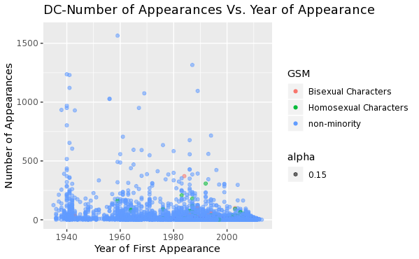

```r
DC %>%
  ggplot(aes(x = YEAR, y = APPEARANCES)) +
  geom_point(aes(color = GSM, group = GSM, alpha = 0.15)) +
  ylim(0, 1600) + ## get rid of outliers
  labs(x = "Year of First Appearance", y = "Number of Appearances", title = "DC-Number of Appearances Vs. Year of Appearance")
```

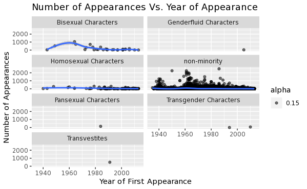

```r
Hero %>%
  ggplot(aes(x = YEAR, y = APPEARANCES)) +
  geom_point(aes(alpha = 0.15)) +
  geom_smooth() +
  facet_wrap(~ GSM, ncol = 2) +
  ylim(0, 2600) + ## get rid of outliers
  labs(x = "Year of First Appearance", y = "Number of Appearances", title = "Number of Appearances Vs. Year of Appearance")
```

It seems that this reinforces the observations above; non-minorities did show up first and more frequently, however minority characters did appear earlier than I had originally thought, although this does better illustrate how little transgender, transvestite, pansexual, and genderfluid characters appear, as well as the fact that they did show up much later in relation to all of the other categories of characters. Bisexual and Homosexual characters (mainly Bisexual) seem to follow the theory that the characters that were introduced at later dates have less appearances, as well.

### Look at GSM, Appearances, and Sex

Something else that may be important is whether or not one sex type is more often clasified as a minority than another, and whether different combinations of minorities and sex have less appearances than others. Since it appears that minorities and sexes outside of male and female appear to have less comic characters overall, perhaps they also have less appearances. Due to this possible pattern, a character that has a combination of a minority as well as less common sex may appear less because of the combination having less characters. Non-minority characters that have more traditional sexes (male and female) may also have more appearances than most.

```r
## make data set that finds the total appearances for each minority type
Hero_totals <-
  Hero %>%
  na.omit() %>%
  group_by(GSM, SEX) %>%
  summarise(total = sum(APPEARANCES))
```

```r
## spread data table based on minority
Hero_wide <-
  Hero_totals %>%
  spread(key = GSM, value = total)
knitr::kable(Hero_wide)
```

| SEX | Bisexual Characters | Genderfluid Characters | Homosexual Characters | non-minority | Pansexual Characters | Transvestites |
| --- | --- | --- | --- | --- | --- | --- |
| Agender Characters | NA | NA | NA | 548 | NA | NA |
| Female Characters | 3137 | NA | 1162 | 82747 | 150 | NA |
| Genderfluid Characters | 532 | 33 | NA | NA | NA | NA |
| Genderless Characters | NA | NA | NA | 39 | NA | NA |
| Male Characters | 1586 | NA | 2500 | 206483 | NA | 500 |

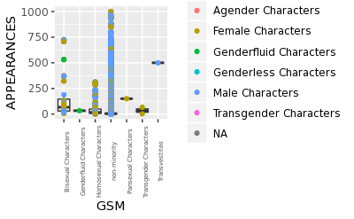

```r
Hero %>%
  ggplot(aes(x = GSM, y = APPEARANCES)) +
  geom_boxplot() +
  geom_point(aes(color = SEX)) +
  ylim(0, 1000) + ## get rid of outliers +
  theme(axis.text.x = element_text(face="plain", size=5, angle=90)) # make the x-axis labels fit
```

```r
  labs(x = "Number of Appearances", y = "Minority Type", title = "Number of Appearances in relation to sex and minority type")
```

```
$x
[1] "Number of Appearances"

$y
[1] "Minority Type"

$title
[1] "Number of Appearances in relation to sex and minority type"

attr(,"class")
[1] "labels"
```

## Conclusions

It appears from the various analyses I did that non-minority male characters are the most common, and also have the most total appearances, which can be expected since there are so many characters within this category. It can also be noted that time (the character’s first appearance) does play a factor, but not as big of one as I had originally thought, as minority characters were introduced as early as the 1940’s. I also found that a character being a minority did not necessarily mean that they had a less common sex. These are all interesting findings, as the talk around this gap between non-minority groups and minorities has been increasing as the years go on. I thought it was especially interesting when the year variable was included in analysis, as a defense these comic companies may use is that most minority characters were included later; however, when looked at, it shows that this isn’t always true, and even if it were, the actual number of minority characters (without looking at appearances) is still far less than that of non-minority.  
One difficulty I faced was with the user-defined function. When I first tried to make the function, the error “non-numeric argument to binary operator in r” popped up everytime I had actually attempted to implement it. I realized that it was probably because I accidentally was trying to apply the function to a character string. I instead went back and spread the data table by minority, and separated the non-minority and minority characters, and adjusted my function accordingly, at which point it worked.